# Summer R

Session 4: Computing variables, joining tables, and working with missing data

Dominic Bordelon, Research Data Librarian, ULS

## Agenda

1. Working with missing data
2. Computing new variables
3. Data viz: faceting
4. Joining tables

## More dplyr

We have used **{dplyr}** to…

- select variables/columns
- sort rows
- filter
- group
- summarize

Today with dplyr we will also:

- create new variables in a data frame
- combine tables

We’ll also use **{naniar}** to help us visualize missing data.

[figure not shown]

```r
library(tidyverse)
library(medicaldata)

# install.packages("naniar")
library(naniar)
```

## Homework review, questions

# Working with missing data

## Representations of missingness in R

These are the ways that R represents missing or unknown information:

- **`NA`**: for a missing value (“not available”)
  - logical constant, length 1
  - can be coerced into vectors of other types (numeric, character, etc.)
- `NULL`: an *object* for an undefined result from a function
- `NaN`: for non-real numbers (“not a number”)
- `Inf` and `-Inf`: for $\infty$ and $-\infty$

We will concern ourselves only with `NA`, but it’s good to know they all exist.

## `NA`: the missing value

`NA` is the value for a missing datum. You can think of it like an empty Excel cell.

What `NA` is *not*:

- `NA` is not character data (`NA` and `"NA"` are different things)
- `NA` is not zero, because zero has a defined position on the number line
- `NA` is not necessarily a problem, depending on your situation (though sometimes it is)

## Conceptual categories of missingness (1)

When examining a data set, you’ll want to see how much data are missing and assess the type of missingness:

- Missing completely at random (MCAR): independent of observable variables, and of parameters of interest
- Missing at random (MAR): missingness depends on observed data, not the missing value
  - Examples: uniform non-response within classes; multiple (varying number) attempts in a process; subject removal due to experimental protocol
  - Impossible to verify statistically—an assumption which needs to be made by the analyst using all real-world information available (i.e., data provenance)

## Conceptual categories of missingness (2)

- Missing, not at random (MNAR): depends on the *missing value*
  - “Nonignorable nonresponse”: a subject does not respond *because* of their abnormal level
  - Treating these observations as representative (i.e., purely random) will introduce a bias into our analysis!

Which type of missingness you have determines whether a bias is introduced, and how you need to account for it statistically.

## Vector functions for working with `NA`

Many functions whose calculations would be tainted by `NA`—for example, `mean()`—accept an `na.rm=TRUE` argument.

These functions are useful with `NA`:

- **`is.na()`** (and `!is.na()`): vectorized check, is the value `NA`?
  - to get a count of `NA` in a vector, wrap with `sum()`: `sum(is.na(polyps$age))`
- **`anyNA()`**: return single T/F, are there any `NA` in the vector?
- `my_vector[!is.na(my_vector)]` strips `NA` from `my_vector`
  - The square brackets `[ ]` are a base R syntax for filtering vectors
- To replace `NA` in `x` $\rightarrow$ a value `y`: `tidyr::replace_na(x, y)`
  - Or `dplyr::coalesce(x, y)` for a more powerful version
- To replace value `y` in `x` $\rightarrow$ `NA`: `na_if(x, y)`

## Data frame functions for working with `NA`

- **`tidyr::drop_na()`** drops (removes) rows with `NA` in any column
  - `drop_na(x, y)` drops rows with `NA` in columns `x`, `y`, or both
- `dplyr::filter()` and `mutate()` can use vector-based functions such as `is.na()`

## Visualizing `NA` with naniar

- `naniar::vis_miss()` shows the `NA` in a data frame
- `gg_miss_upset()`: patterns among variables
- `gg_miss_fct()`: patterns among factor levels (categorical levels)

There are several more, but the three above are most useful. You can browse the [naniar gallery](https://naniar.njtierney.com/articles/naniar-visualisation.html) or try these out with any data frame.

# ICA 4.1: `NA`, missing data

# Computing new variables

## `mutate()`: add a new column

- `dplyr::mutate(.data, ...)` creates new columns, usually from existing ones.
- The `...` argument(s) are expression(s) evaluated for each row, forming values for the new column.
- Use a named argument to assign a name to the column
- OK to use an existing name—but it will overwrite that column, of course

```r
# create a BMI variable in the medicaldata::smartpill data set:
names(smartpill)[1:6]
```

```
[1] "Group"  "Gender" "Race"   "Height" "Weight" "Age"
```

```r
smartpill %>%
  mutate(BMI = Weight / ((Height*0.01)^2),
         .before = Height) %>%
  select(1:7) %>%
  head(6)
```

```
  Group Gender Race      BMI Height    Weight Age
1     0      1   NA 30.51515 182.88 102.05820  25
2     0      1   NA 31.38078 180.34 102.05820  39
3     0      1   NA 20.92052 180.34  68.03880  44
4     0      1   NA 22.74157 175.26  69.85317  53
5     0      0   NA 19.33440 152.40  44.90561  57
6     0      1   NA 27.57392 185.42  94.80073  43
```

## Convert an existing column’s data type

Example: like many plaintext-sourced data sets, `covid_testing` columns are auto-encoded as numeric or character upon import. Now, we want `gender` to be represented properly as a categorical variable or *factor*.

```r
covid_testing %>%
  select(subject_id, gender) %>%
  summary()
```

```
   subject_id       gender
 Min.   :    1   Length:15524
 1st Qu.: 2330   Class :character
 Median : 5268   Mode  :character
 Mean   : 5571
 3rd Qu.: 8636
 Max.   :12346
```

```r
covid_testing %>%
  mutate(gender = as_factor(gender)) %>%
  select(subject_id, gender) %>%
  summary()
```

```
   subject_id       gender
 Min.   :    1   female:7832
 1st Qu.: 2330   male  :7692
 Median : 5268
 Mean   : 5571
 3rd Qu.: 8636
 Max.   :12346
```

## `if_else()`: apply decision logic to values

- When we want to dictate decision-making in the column’s value, we need to use Boolean programming logic
- Use `if_else(condition, true, false)` within the `mutate()` call.

```r
covid_testing %>%
  select(1, 4, age) %>%   # ignore most columns
  mutate(treatment_group = if_else(subject_id < 5000,
                                   "placebo",
                                   "treatment"),
         .after = subject_id) %>%
  slice_sample(n=6)       # randomly sample 6 rows
```

```
# A tibble: 6 × 4
  subject_id treatment_group gender   age
       <dbl> <chr>           <chr>  <dbl>
1       7753 treatment       male     1
2        501 placebo         female   2
3         88 placebo         female  30
4       1745 placebo         male    38
5       3542 placebo         female   0.1
6       6392 treatment       female   8
```

## `case_when()`: >2 decision cases

- For if-else logic beyond two choices, `case_when()` is recommended
- Case expressions are evaluated in order until one of them returns `TRUE`

```r
# note the syntax; ~ reads like "then"

covid_testing %>%
  select(1, 4, age) %>%
  mutate(treatment_group = case_when(
    subject_id <= 2300 ~ "placebo",
    subject_id <= 5200 ~ "group A",
    subject_id <= 8600 ~ "group B",
    .default = "group C"      # captures everything above 8600
  ),
         .after = subject_id) %>%
  slice_sample(n=8)
```

```
# A tibble: 8 × 4
  subject_id treatment_group gender   age
       <dbl> <chr>           <chr>  <dbl>
1      10261 group C         female  26
2       3485 group A         male    15
3       1960 placebo         male     0
4       5125 group A         male     5
5       1045 placebo         female  46
6       1242 placebo         female   0.7
7       8410 group B         female   2
8       1977 placebo         female  18
```

# Data viz: faceting

## `facet_grid()` and `facet_wrap()`: add faceting to a ggplot

- Faceting of a discrete or categorical variable, AKA small multiples, means breaking out mini-plots for each of the present values/levels.
- Layouts: columns, rows, a grid, or rectangles that stack/flow
- Awkward gotcha: wrap variable/column names in `vars()` (see examples on following slides)
- ⚠ Important rule of facets: axes must always match especially in scale! (The `facet_` functions take care of this for us, but be careful if you ever make your own manually or in a different setting.)

Pre-faceting, scatter plot of pandemic day and patient age:

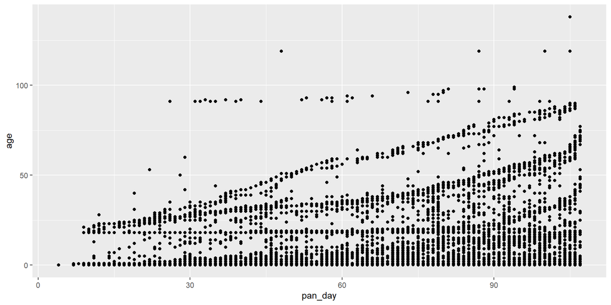

```r
covid_testing %>%
  ggplot() +
  geom_point(aes(pan_day, age))
```

Gender faceting into columns:

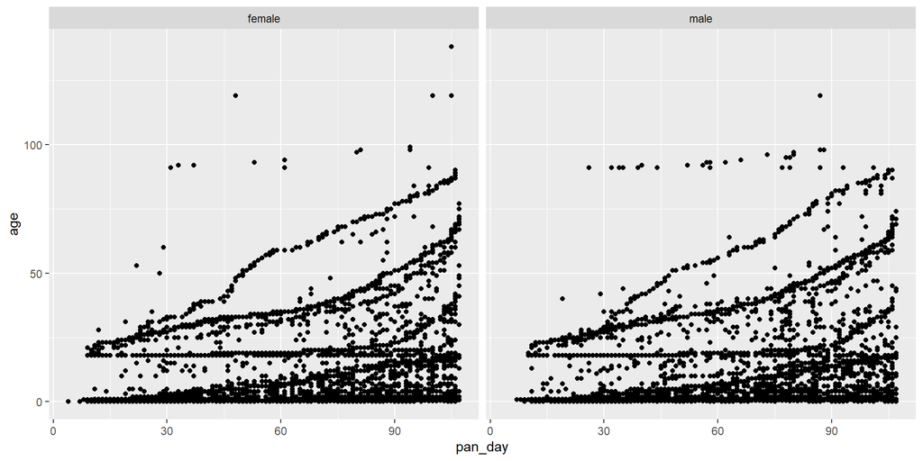

```r
covid_testing %>%
  ggplot() +
  geom_point(aes(pan_day, age)) +
  facet_grid(cols=vars(gender))
```

For more than ~3 groups, use `facet_wrap()` to flow the subplots onto multiple rows:

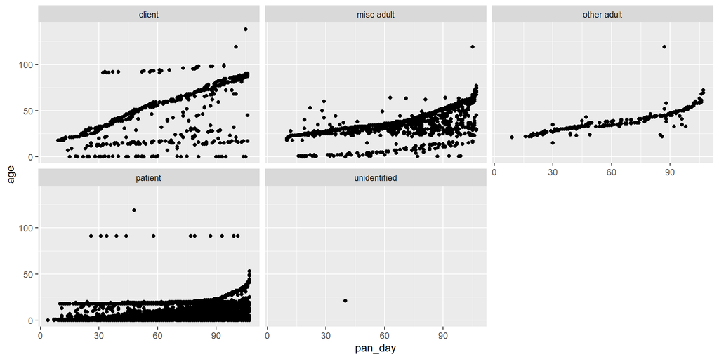

```r
covid_testing %>%
  ggplot() +
  geom_point(aes(pan_day, age)) +
  facet_wrap(vars(demo_group))
```

Lastly to facet by *two* variables, in a grid: (note the limited legibility of narrow plots!)

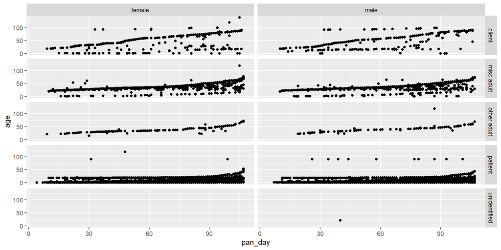

```r
covid_testing %>%
  ggplot() +
  geom_point(aes(pan_day, age)) +
  facet_grid(cols=vars(gender),
             rows=vars(demo_group))
```

# ICA 4.2: New variables, faceting

# Joining tables

## Relational data and table joins

- Much of the world’s data lives in *relational database management systems* (RDBMSes), or simply “relational databases”
- Sometimes you might work with one of these directly; other times you might receive CSV files which originated in a RDBMS
- “Relational” == Table A has a relationship to Table B, via column X which appears in both tables (“foreign key relationship”)
- Why relational?
  - One big table gets to be unmanageable, but we also don’t want to duplicate info in the multiple places that we need it
  - Often-repeated values (e.g., a drug name) can be more efficiently stored/retrieved if they are replaced by a number, which points to the human-readable name.

*Joining* synthesizes a new a table from two or more parent tables.

## Relationship types

- **One-to-one relationships**: one row in Table A corresponds to one row in Table B
- **One-to-many relationships**: “lookup” function; controlled vocabulary; Table B describes categories that are referenced in Table A
- **Many-to-many relationships**: there are many subjects (Table A), and many genetic markers (Table B); a patient may have an unspecified number of markers and vice versa, a relationship described in Table C

It can be helpful to have these relationships in mind when thinking about different ways we might want to join tables together.

## Types of joins

Join type asks, “if I have unpaired rows when I join Tables A and B, what do I do with those rows?”

- Full join: keep all rows from both tables, filling `NA` as needed
- Inner join: keep only rows that appear in *both* tables
- Left join: inner join + keep all of the rows from the *left* table, filling `NA` as needed
- Right join: inner join + keep all of the rows from the *right* table, filling `NA` as needed
- Filtering joins: filter rows of Table A based on presence/absence of the row’s ID in Table B

Each of the above joins might produce a different number of rows.

```r
lg_sample <- read_csv("data/lg_sample.csv")
asa_status <- read_csv("data/asa_status.csv")
```

Consider these two tables:

```r
# 6-row sample of licorice_gargle

lg_sample %>%
  select(1:3)
```

```
# A tibble: 6 × 3
  preOp_gender preOp_asa preOp_calcBMI
         <dbl>     <dbl>         <dbl>
1            0         2          31.3
2            0         1          32.3
3            1         3          30.5
4            0         3          32.2
5            1        NA          36.3
6            0         2          28.0
```

```r
# listing of ASA statuses

asa_status
```

```
# A tibble: 4 × 2
  asa_status_id asa_status
          <dbl> <chr>
1             1 a normal healthy patient
2             2 a patient with mild systemic disease
3             3 a patient with severe systemic disease
4             4 UNUSED CATEGORY
```

## `full_join()`: combine all data

```r
lg_sample %>%
  select(1:4) %>%
  full_join(y = asa_status, by = join_by(preOp_asa == asa_status_id))
```

```
# A tibble: 7 × 5
  preOp_gender preOp_asa preOp_calcBMI preOp_age asa_status
         <dbl>     <dbl>         <dbl>     <dbl> <chr>
1            0         2          31.3        80 a patient with mild systemic d…
2            0         1          32.3        58 a normal healthy patient
3            1         3          30.5        65 a patient with severe systemic…
4            0         3          32.2        54 a patient with severe systemic…
5            1        NA          36.3        56 <NA>
6            0         2          28.0        68 a patient with mild systemic d…
7           NA         4          NA          NA UNUSED CATEGORY
```

Note 7 rows: 5 with matches in both tables; one Table A patient with no pre-op ASA status reported; and one Table B unused category.

## `inner_join()`: keep only rows from both tables

```r
lg_sample %>%
  select(1:4) %>%
  inner_join(y = asa_status, by = join_by(preOp_asa == asa_status_id))
```

```
# A tibble: 5 × 5
  preOp_gender preOp_asa preOp_calcBMI preOp_age asa_status
         <dbl>     <dbl>         <dbl>     <dbl> <chr>
1            0         2          31.3        80 a patient with mild systemic d…
2            0         1          32.3        58 a normal healthy patient
3            1         3          30.5        65 a patient with severe systemic…
4            0         3          32.2        54 a patient with severe systemic…
5            0         2          28.0        68 a patient with mild systemic d…
```

Now we have only the five rows that appear in both tables.

## `left_join()`: keep rows from x

```r
lg_sample %>%
  select(1:4) %>%
  left_join(y = asa_status, by = join_by(preOp_asa == asa_status_id))
```

```
# A tibble: 6 × 5
  preOp_gender preOp_asa preOp_calcBMI preOp_age asa_status
         <dbl>     <dbl>         <dbl>     <dbl> <chr>
1            0         2          31.3        80 a patient with mild systemic d…
2            0         1          32.3        58 a normal healthy patient
3            1         3          30.5        65 a patient with severe systemic…
4            0         3          32.2        54 a patient with severe systemic…
5            1        NA          36.3        56 <NA>
6            0         2          28.0        68 a patient with mild systemic d…
```

Now we have increased to 6 rows, because we kept all of the left table, including the patient with no pre-op ASA status reported.

## `right_join()`: keep rows from y

```r
lg_sample %>%
  select(1:4) %>%
  right_join(y = asa_status, by = join_by(preOp_asa == asa_status_id))
```

```
# A tibble: 6 × 5
  preOp_gender preOp_asa preOp_calcBMI preOp_age asa_status
         <dbl>     <dbl>         <dbl>     <dbl> <chr>
1            0         2          31.3        80 a patient with mild systemic d…
2            0         1          32.3        58 a normal healthy patient
3            1         3          30.5        65 a patient with severe systemic…
4            0         3          32.2        54 a patient with severe systemic…
5            0         2          28.0        68 a patient with mild systemic d…
6           NA         4          NA          NA UNUSED CATEGORY
```

6 rows again, but this time we have dropped the nonreporting patient, and we see instead the unused category.

## `semi_join()`, `anti_join()`: filter x vs. y

Filtering joins decide which rows to keep from x, based on the presence (or absence) of the value in y

Example: you applied inclusion criteria to get a list of patient ID’s to include in analysis, and now you would like to filter just those patients’ records into a data frame.

```r
inclusion_ids <- tibble(subject_id = c(9134, 663, 5408))

covid_testing %>%
  semi_join(y = inclusion_ids, by = join_by(subject_id))
```

```
# A tibble: 3 × 17
  subject_id fake_…¹ fake_…² gender pan_day test_id clini…³ result demo_…⁴   age
       <dbl> <chr>   <chr>   <chr>    <dbl> <chr>   <chr>   <chr>  <chr>   <dbl>
1       9134 grunt   rivers  male         7 covid   clinic… negat… patient   0.8
2        663 ithoke  targar… male         9 covid   clinic… negat… patient   0.8
3       5408 alia    ryswell female      10 covid   clinic… negat… patient   0.9
# … with 7 more variables: drive_thru_ind <dbl>, ct_result <dbl>,
#   orderset <dbl>, payor_group <chr>, patient_class <chr>, col_rec_tat <dbl>,
#   rec_ver_tat <dbl>, and abbreviated variable names ¹fake_first_name,
#   ²fake_last_name, ³clinic_name, ⁴demo_group
```

# ICA 4.3: Joins

# Wrap up

## Conclusion

We learned about:

- finding and visualizing missing data (`NA`)
- computing new columns in a data frame
- joining tables to combine data

Next time: working with factors; pivoting data

Summer R 4: Computing variables; joining; missing data